# Mercedes-Benz Greener Manufacturing

## Reduce the time a Mercedes-Benz spends on the test bench

Problem Statement Scenario: Since the first automobile, the Benz Patent Motor Car in 1886, Mercedes-Benz has stood for important automotive innovations. These include the passenger safety cell with a crumple zone, the airbag, and intelligent assistance systems. Mercedes-Benz applies for nearly 2000 patents per year, making the brand the European leader among premium carmakers. Mercedes-Benz is the leader in the premium car industry. With a huge selection of features and options, customers can choose the customized Mercedes-Benz of their dreams.

To ensure the safety and reliability of every unique car configuration before they hit the road, the company’s engineers have developed a robust testing system. As one of the world’s biggest manufacturers of premium cars, safety and efficiency are paramount on Mercedes-Benz’s production lines. However, optimizing the speed of their testing system for many possible feature combinations is complex and time-consuming without a powerful algorithmic approach.

You are required to reduce the time that cars spend on the test bench. Others will work with a dataset representing different permutations of features in a Mercedes-Benz car to predict the time it takes to pass testing. Optimal algorithms will contribute to faster testing, resulting in lower carbon dioxide emissions without reducing Mercedes-Benz’s standards.

```python
import pandas as pd
import matplotlib.pyplot as plt
import numpy as np
import seaborn as sns
```

# Data Preprocssing

## Load dataset

```python
# loading the dataset
df = pd.read_csv('./resources/mercedez_benz_train.csv')
df2  = pd.read_csv('./resources/mercedez_benz_test.csv')
```

#### Dimensionality Check

```python
df.info()
# Total columns 378
```

```
<class 'pandas.core.frame.DataFrame'>
RangeIndex: 4209 entries, 0 to 4208
Columns: 378 entries, ID to X385
dtypes: float64(1), int64(369), object(8)
memory usage: 12.1+ MB
```

```python
df.head()
```

|  | ID | y | X0 | X1 | X2 | X3 | X4 | X5 | X6 | X8 | ... | X375 | X376 | X377 | X378 | X379 | X380 | X382 | X383 | X384 | X385 |
| --- | --- | --- | --- | --- | --- | --- | --- | --- | --- | --- | --- | --- | --- | --- | --- | --- | --- | --- | --- | --- | --- |
| 0 | 0 | 130.81 | k | v | at | a | d | u | j | o | ... | 0 | 0 | 1 | 0 | 0 | 0 | 0 | 0 | 0 | 0 |
| 1 | 6 | 88.53 | k | t | av | e | d | y | l | o | ... | 1 | 0 | 0 | 0 | 0 | 0 | 0 | 0 | 0 | 0 |
| 2 | 7 | 76.26 | az | w | n | c | d | x | j | x | ... | 0 | 0 | 0 | 0 | 0 | 0 | 1 | 0 | 0 | 0 |
| 3 | 9 | 80.62 | az | t | n | f | d | x | l | e | ... | 0 | 0 | 0 | 0 | 0 | 0 | 0 | 0 | 0 | 0 |
| 4 | 13 | 78.02 | az | v | n | f | d | h | d | n | ... | 0 | 0 | 0 | 0 | 0 | 0 | 0 | 0 | 0 | 0 |

5 rows × 378 columns

```python
df2.head(5)
# df2 don't have response variable so not considering it
```

|  | ID | X0 | X1 | X2 | X3 | X4 | X5 | X6 | X8 | X10 | ... | X375 | X376 | X377 | X378 | X379 | X380 | X382 | X383 | X384 | X385 |
| --- | --- | --- | --- | --- | --- | --- | --- | --- | --- | --- | --- | --- | --- | --- | --- | --- | --- | --- | --- | --- | --- |
| 0 | 1 | az | v | n | f | d | t | a | w | 0 | ... | 0 | 0 | 0 | 1 | 0 | 0 | 0 | 0 | 0 | 0 |
| 1 | 2 | t | b | ai | a | d | b | g | y | 0 | ... | 0 | 0 | 1 | 0 | 0 | 0 | 0 | 0 | 0 | 0 |
| 2 | 3 | az | v | as | f | d | a | j | j | 0 | ... | 0 | 0 | 0 | 1 | 0 | 0 | 0 | 0 | 0 | 0 |
| 3 | 4 | az | l | n | f | d | z | l | n | 0 | ... | 0 | 0 | 0 | 1 | 0 | 0 | 0 | 0 | 0 | 0 |
| 4 | 5 | w | s | as | c | d | y | i | m | 0 | ... | 1 | 0 | 0 | 0 | 0 | 0 | 0 | 0 | 0 | 0 |

5 rows × 377 columns

```python
df.drop(columns='ID', inplace=True)
# ID column is not required
```

```python
df.describe(include='all')
```

|  | y | X0 | X1 | X2 | X3 | X4 | X5 | X6 | X8 | X10 | ... | X375 | X376 | X377 | X378 | X379 | X380 | X382 | X383 | X384 | X385 |
| --- | --- | --- | --- | --- | --- | --- | --- | --- | --- | --- | --- | --- | --- | --- | --- | --- | --- | --- | --- | --- | --- |
| count | 4209.000000 | 4209 | 4209 | 4209 | 4209 | 4209 | 4209 | 4209 | 4209 | 4209.000000 | ... | 4209.000000 | 4209.000000 | 4209.000000 | 4209.000000 | 4209.000000 | 4209.000000 | 4209.000000 | 4209.000000 | 4209.000000 | 4209.000000 |
| unique | NaN | 47 | 27 | 44 | 7 | 4 | 29 | 12 | 25 | NaN | ... | NaN | NaN | NaN | NaN | NaN | NaN | NaN | NaN | NaN | NaN |
| top | NaN | z | aa | as | c | d | w | g | j | NaN | ... | NaN | NaN | NaN | NaN | NaN | NaN | NaN | NaN | NaN | NaN |
| freq | NaN | 360 | 833 | 1659 | 1942 | 4205 | 231 | 1042 | 277 | NaN | ... | NaN | NaN | NaN | NaN | NaN | NaN | NaN | NaN | NaN | NaN |
| mean | 100.669318 | NaN | NaN | NaN | NaN | NaN | NaN | NaN | NaN | 0.013305 | ... | 0.318841 | 0.057258 | 0.314802 | 0.020670 | 0.009503 | 0.008078 | 0.007603 | 0.001663 | 0.000475 | 0.001426 |
| std | 12.679381 | NaN | NaN | NaN | NaN | NaN | NaN | NaN | NaN | 0.114590 | ... | 0.466082 | 0.232363 | 0.464492 | 0.142294 | 0.097033 | 0.089524 | 0.086872 | 0.040752 | 0.021796 | 0.037734 |
| min | 72.110000 | NaN | NaN | NaN | NaN | NaN | NaN | NaN | NaN | 0.000000 | ... | 0.000000 | 0.000000 | 0.000000 | 0.000000 | 0.000000 | 0.000000 | 0.000000 | 0.000000 | 0.000000 | 0.000000 |
| 25% | 90.820000 | NaN | NaN | NaN | NaN | NaN | NaN | NaN | NaN | 0.000000 | ... | 0.000000 | 0.000000 | 0.000000 | 0.000000 | 0.000000 | 0.000000 | 0.000000 | 0.000000 | 0.000000 | 0.000000 |
| 50% | 99.150000 | NaN | NaN | NaN | NaN | NaN | NaN | NaN | NaN | 0.000000 | ... | 0.000000 | 0.000000 | 0.000000 | 0.000000 | 0.000000 | 0.000000 | 0.000000 | 0.000000 | 0.000000 | 0.000000 |
| 75% | 109.010000 | NaN | NaN | NaN | NaN | NaN | NaN | NaN | NaN | 0.000000 | ... | 1.000000 | 0.000000 | 1.000000 | 0.000000 | 0.000000 | 0.000000 | 0.000000 | 0.000000 | 0.000000 | 0.000000 |
| max | 265.320000 | NaN | NaN | NaN | NaN | NaN | NaN | NaN | NaN | 1.000000 | ... | 1.000000 | 1.000000 | 1.000000 | 1.000000 | 1.000000 | 1.000000 | 1.000000 | 1.000000 | 1.000000 | 1.000000 |

11 rows × 377 columns

```python
# Check for null values
df.isnull().sum().sum()
# there should not be any null values
```

```
0
```

```python
# Seperate X and y
X = df.drop(columns=['y'], axis=1)
y = df['y']
```

### Normality test

#### Shapiro-Wilk Test

```python
from scipy.stats import shapiro
```

```python
#The null-hypothesis of this test is that the population is normally distributed
stat, p = shapiro(y)
print('Statastics=%0.3f, p=%0.3f' % (stat, p))
if p < 0.05:
    # reject null hypothesis
    print("Sample is not normally distrubuted")
else:
    print("Sample is not distrubuted")
```

```
Statastics=0.939, p=0.000
Sample is not normally distrubuted
```

## Check for outliers

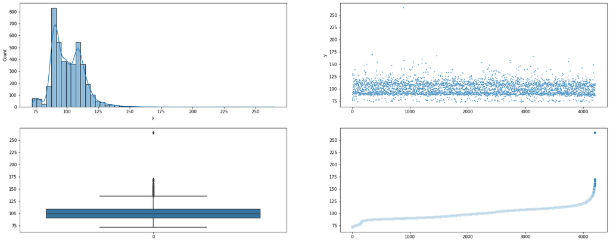

```python
fig, ((plt1,plt2), (plt3,plt4)) = plt.subplots(2,2, figsize=(25,10))
sns.histplot(y, bins=50, ax=plt1, kde=True)
sns.scatterplot(data=y, ax=plt2, s=5)
sns.boxplot(data=y, ax=plt3)
sns.scatterplot(data=y.sort_values().values, ax=plt4)
```

## Outliers treatment

```python
Q1 = y.quantile(0.25)
Q3 = y.quantile(0.75)
IQR = Q3 -Q1
print('Q1:', Q1, 'Q3:', Q3, 'IQR:', IQR)
```

```
Q1: 90.82 Q3: 109.01 IQR: 18.190000000000012
```

```python
IQR_FACTOR = 1.5
data_range =  {'low' :(Q1 - IQR_FACTOR*IQR), 'high': (Q3 + IQR_FACTOR*IQR)}
data_range
```

```
{'low': 63.534999999999975, 'high': 136.29500000000002}
```

```python
y_trimmed = y.loc[(y > data_range['low']) & (y < data_range['high'])]
```

```python
df_trimmed = df.loc[y_trimmed.index]
X_trimmed = X.loc[y_trimmed.index]
```

```python
outliers = y.loc[(y < data_range['low']) | (y > data_range['high'])]
```

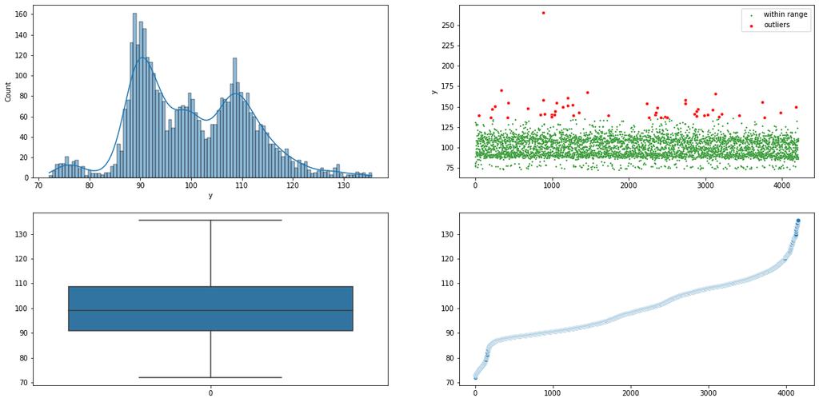

```python
fig, ((plt1,plt2), (plt3,plt4)) = plt.subplots(2,2, figsize=(20,10))
sns.histplot(y_trimmed, bins=100, ax=plt1, kde=True,)
sns.scatterplot(data=y_trimmed, ax=plt2, s=5, c=['g'], label="within range")
sns.scatterplot(data=outliers, ax=plt2, s=20, c=['r'], label="outliers")
sns.boxplot(data=y_trimmed, ax=plt3)
sns.scatterplot(data=y_trimmed.sort_values().values, ax=plt4)
```

```python
X = X_trimmed
y = y_trimmed
df = df_trimmed
```

```python
#The null-hypothesis of this test is that the population is normally distributed
stat, p = shapiro(y)
print('Statastics=%0.3f, p=%0.3f' % (stat, p))
if p < 0.05:
    # reject null hypothesis
    print("Sample is not normally distrubuted")
else:
    print("Sample is not distrubuted")
```

```
Statastics=0.977, p=0.000
Sample is not normally distrubuted
```